```python
import tensorflow as tf
from tensorflow.keras import layers, models
import numpy as np
import matplotlib.pyplot as plt
from tensorflow.keras.datasets import mnist
from tensorflow.keras.utils import to_categorical
from tensorflow.keras.models import load_model
```

$Autor: Johana Cómbita Niño$

# Introduction to ConvNets: Classifying handwritten numbers

Let's take a look at a simple example of a convnet. We will use it to classify the MNIST dataset, which is an open dataset containing handwritten numbers.

[figure not shown]

Let's create a first basic convnet. It's a stack of 'Conv2D' and 'MaxPooling2D' layers. The important thing to note is that a convnet takes as input tensors of size `(image_height, image_width, image_channels)`. To do this we must first find out the size of the images in our dataset.

The network must have the following layers:

- A convolutional layer (Conv2D) with 32 3x3 filters and relu activation. In this first layer you must indicate the size of the input (input_shape).
- A second layer of Max Pooling (MaxPooling2D) of 2x2
- A third convolutional layer with 64 3x3 filters and relu activation
- A fourth layer of 2x2 Max Pooling (MaxPooling2D)
- A fifth convolutional layer of 64 3x3 filters and relu activation

You'll know you've done it right when the model.summary() output is:

[figure not shown]

Con base en las indiaciones dadas para cada capa, se crea la red. La primera capa aprende 32 filtros con una ventana tamaño 3x3, donde cada filtro se desliza (convolution) sobre la imagen de entrada, produciendo 32 mapas de activación. La activación ReLU (Rectified Linear Unit) se utiliza para añadir no linealidad y ayuda a la red a capturar patrones más complejos. La segunda capa realiza un pooling de 2×2, reduciendo la dimensión espacial de los mapas de activación; donde, al reducir la resolución espacial hace que la red se concentre en características más globales y se reducen los parámetros, evitando sobreajuste y bajando el coste computacional. Luego se aplica otra convolución sobre la salida reducida anterior con 64 filtros 3x3 y la función de activación ReLu, para aprender características más complejas. En una cuarta capa se reduce nuevamente la dimensión especial 2x2; y finalmente, una tercera convolución con 64 filtros de 3x3, donde en esta fase la red ya se encuentra extrayendo rasgos de mayor nivel, combinando la información de las capas anteriores.

```python
# Definición del modelo
model = models.Sequential()

#Capa Conv2D con 32 filtros 3x3, activación ReLU y forma de entrada (28, 28, 1)
model.add(layers.Conv2D(32, (3, 3), activation='relu', input_shape=(28, 28, 1)))
# Capa de MaxPooling2D 2x2
model.add(layers.MaxPooling2D((2, 2)))
#Capa Conv2D con 64 filtros 3x3 y activación ReLU
model.add(layers.Conv2D(64, (3, 3), activation='relu'))
#Capa de MaxPooling2D 2x2
model.add(layers.MaxPooling2D((2, 2)))
# Capa Conv2D con 64 filtros 3x3, activación ReLU
model.add(layers.Conv2D(64, (3, 3), activation='relu'))

#salida
model.summary()
```

```
Model: "sequential"
_________________________________________________________________
 Layer (type)                Output Shape              Param #
=================================================================
 conv2d (Conv2D)             (None, 26, 26, 32)        320

 max_pooling2d (MaxPooling2  (None, 13, 13, 32)        0
 D)

 conv2d_1 (Conv2D)           (None, 11, 11, 64)        18496

 max_pooling2d_1 (MaxPoolin  (None, 5, 5, 64)          0
 g2D)

 conv2d_2 (Conv2D)           (None, 3, 3, 64)          36928

=================================================================
Total params: 55744 (217.75 KB)
Trainable params: 55744 (217.75 KB)
Non-trainable params: 0 (0.00 Byte)
_________________________________________________________________
```

You can see above that the output of each Conv2D and MaxPooling2D layer is a 3D tensor of dimensions (height, width, channels). The width and height tend to decrease as we go deeper into the network. The number of channels is controlled by the first argument passed to the Conv2D layers (e.g. 32 or 64).

The next step would be to give our last tensor (of dimensions (3, 3, 64)) as input to a densely connected network. These classifiers process vectors, which are 1D, while our output is a 3D tensor. So first we will have to flatten our 3D output and convert it to 1D and then add a few dense layers:

- Add a first layer of 64 neurons
- Add a last layer of 10 neurons (as many as you can sort) and softmax activation
- You'll know you've done well when the summary looks like this:

[figure not shown]

Después de la última capa convolucional se obtiene un tensor 3D de dimensiones (3, 3, 64), donde se contienen características de alto nivel de la imagen. Sin embargo, para poder generar una salida que clasifique los números hay que conectarlo a una capa densa que opera sobre vectores 1D, por lo cual se debe convertir el volumen 3D que sale de la última convolución en un vector 1D. La salida (3, 3, 64) tiene un total de 3 * 3 * 64 = 576 valores, los cuales son aplanados con la función Flatten. Seguidamente, es posible conectar la capa densa con 64 neuronas y la función de activación ReLu, para luego añadir la capa densa con las 10 neuronas de salida para cada número, con una función de activación Softmax. Esta capa es el clasificador que reciba las características extraídas y decida a qué clase pertenece la imagen. Esta última capa cuenta con una función de activación diferente debido a que cada neurona de esta capa corresponderá a la probabilidad estimada de que la imagen pertenezca a la clase x (valores de 0 a 9), y esta función es usada para problemas de clasificación múltiple ya que fuerza a que la salida sea un vector de probabilidades que sumen 1.

```python
# aplanar la salida de la capa anterior
model.add(layers.Flatten())
#capa densa con 64 neuronas y activación ReLU
model.add(layers.Dense(64, activation='relu'))
#capa de salida con 10 neuronas y activación softmax
model.add(layers.Dense(10, activation='softmax'))

model.summary()
```

```
Model: "sequential"
_________________________________________________________________
 Layer (type)                Output Shape              Param #
=================================================================
 conv2d (Conv2D)             (None, 26, 26, 32)        320

 max_pooling2d (MaxPooling2  (None, 13, 13, 32)        0
 D)

 conv2d_1 (Conv2D)           (None, 11, 11, 64)        18496

 max_pooling2d_1 (MaxPoolin  (None, 5, 5, 64)          0
 g2D)

 conv2d_2 (Conv2D)           (None, 3, 3, 64)          36928

 flatten (Flatten)           (None, 576)               0

 dense (Dense)               (None, 64)                36928

 dense_1 (Dense)             (None, 10)                650

=================================================================
Total params: 93322 (364.54 KB)
Trainable params: 93322 (364.54 KB)
Non-trainable params: 0 (0.00 Byte)
_________________________________________________________________
```

As you can see, our dimensional output `(3, 3, 64)` has been flattened into a vector of dimension `(576,)`, before entering the two dense layers.

We are now going to train our network with the images from the MNIST dataset.

We then load the dataset and put it into vectors: train_images, train_labels, test_images, test_labels

Before you continue, print:

- What is the size of the training dataset?
- What does the training dataset look like?
- What do the training labels look like?
- Print the fourth image of the training dataset

Se cargan los datos de MNIST y se hace la divisón del conjunto de Train y test.

```python
# carga de datos MNIST
(train_images, train_labels), (test_images, test_labels) = mnist.load_data()

# shape de los datos
train_images.shape, train_labels.shape, test_images.shape, test_labels.shape
```

```
((60000, 28, 28), (60000,), (10000, 28, 28), (10000,))
```

Respondiendo a las preguntas: ¿Cuál es el tamaño del conjunto de datos de entrenamiento?

```python
#tamaño del conjunto de entrenamiento
print("Tamaño del conjunto de entrenamiento (train_images shape):", train_images.shape)
```

```
Tamaño del conjunto de entrenamiento (train_images shape): (60000, 28, 28)
```

¿Qué aspecto tiene el conjunto de datos de entrenamiento? El conjunto de entrenamiento tiene forma (60000, 28, 28), lo cual significa que hay 60.000 imágenes en escala de grises, y cada imagen se representa mediante una matriz de 28×28 píxeles. Los valores de cada píxel suelen ser enteros de 8 bits (0 a 255), donde 0 significa un píxel negro y 255 un píxel blanco. Por ejemplo, train_images[0] es la primera imagen, que consta de una matriz de 28 filas y 28 columnas, representando la intensidad de cada píxel del dígito escrito a mano.

```python
#aspecto
train_images[0]
```

```
array([[  0,   0,   0,   0,   0,   0,   0,   0,   0,   0,   0,   0,   0,
          0,   0,   0,   0,   0,   0,   0,   0,   0,   0,   0,   0,   0,
          0,   0],
       [  0,   0,   0,   0,   0,   0,   0,   0,   0,   0,   0,   0,   0,
          0,   0,   0,   0,   0,   0,   0,   0,   0,   0,   0,   0,   0,
          0,   0],
       [  0,   0,   0,   0,   0,   0,   0,   0,   0,   0,   0,   0,   0,
          0,   0,   0,   0,   0,   0,   0,   0,   0,   0,   0,   0,   0,
          0,   0],
       [  0,   0,   0,   0,   0,   0,   0,   0,   0,   0,   0,   0,   0,
          0,   0,   0,   0,   0,   0,   0,   0,   0,   0,   0,   0,   0,
          0,   0],
       [  0,   0,   0,   0,   0,   0,   0,   0,   0,   0,   0,   0,   0,
          0,   0,   0,   0,   0,   0,   0,   0,   0,   0,   0,   0,   0,
          0,   0],
       [  0,   0,   0,   0,   0,   0,   0,   0,   0,   0,   0,   0,   3,
         18,  18,  18, 126, 136, 175,  26, 166, 255, 247, 127,   0,   0,
          0,   0],
       [  0,   0,   0,   0,   0,   0,   0,   0,  30,  36,  94, 154, 170,
        253, 253, 253, 253, 253, 225, 172, 253, 242, 195,  64,   0,   0,
          0,   0],
       [  0,   0,   0,   0,   0,   0,   0,  49, 238, 253, 253, 253, 253,
        253, 253, 253, 253, 251,  93,  82,  82,  56,  39,   0,   0,   0,
          0,   0],
       [  0,   0,   0,   0,   0,   0,   0,  18, 219, 253, 253, 253, 253,
        253, 198, 182, 247, 241,   0,   0,   0,   0,   0,   0,   0,   0,
          0,   0],
       [  0,   0,   0,   0,   0,   0,   0,   0,  80, 156, 107, 253, 253,
        205,  11,   0,  43, 154,   0,   0,   0,   0,   0,   0,   0,   0,
          0,   0],
       [  0,   0,   0,   0,   0,   0,   0,   0,   0,  14,   1, 154, 253,
         90,   0,   0,   0,   0,   0,   0,   0,   0,   0,   0,   0,   0,
          0,   0],
       [  0,   0,   0,   0,   0,   0,   0,   0,   0,   0,   0, 139, 253,
        190,   2,   0,   0,   0,   0,   0,   0,   0,   0,   0,   0,   0,
          0,   0],
       [  0,   0,   0,   0,   0,   0,   0,   0,   0,   0,   0,  11, 190,
        253,  70,   0,   0,   0,   0,   0,   0,   0,   0,   0,   0,   0,
          0,   0],
       [  0,   0,   0,   0,   0,   0,   0,   0,   0,   0,   0,   0,  35,
```

[output cut: 29 more lines]

```
       [  0,   0,   0,   0,  55, 172, 226, 253, 253, 253, 253, 244, 133,
         11,   0,   0,   0,   0,   0,   0,   0,   0,   0,   0,   0,   0,
          0,   0],
       [  0,   0,   0,   0, 136, 253, 253, 253, 212, 135, 132,  16,   0,
          0,   0,   0,   0,   0,   0,   0,   0,   0,   0,   0,   0,   0,
          0,   0],
       [  0,   0,   0,   0,   0,   0,   0,   0,   0,   0,   0,   0,   0,
          0,   0,   0,   0,   0,   0,   0,   0,   0,   0,   0,   0,   0,
          0,   0],
       [  0,   0,   0,   0,   0,   0,   0,   0,   0,   0,   0,   0,   0,
          0,   0,   0,   0,   0,   0,   0,   0,   0,   0,   0,   0,   0,
          0,   0],
       [  0,   0,   0,   0,   0,   0,   0,   0,   0,   0,   0,   0,   0,
          0,   0,   0,   0,   0,   0,   0,   0,   0,   0,   0,   0,   0,
          0,   0]], dtype=uint8)
```

Seguidamente, ¿Qué aspecto tienen las etiquetas de entrenamiento? Se trata de un array de 60.000 posiciones, donde cada una tiene una etiqueta de 0 a 9.

```python
#tamaño de etiquetas de entrenamiento
print("Shape de train_labels:", train_labels.shape)
#muestra de los primeros 10 elementos de train_labels
print("Ejemplo de etiquetas de entrenamiento (primeras 10):", train_labels[:10])
```

```
Shape de train_labels: (60000,)
Ejemplo de etiquetas de entrenamiento (primeras 10): [5 0 4 1 9 2 1 3 1 4]
```

Se imprima la cuarta imagen del conjunto de datos de entrenamiento a manera de ejemplo del contenido del dataset.

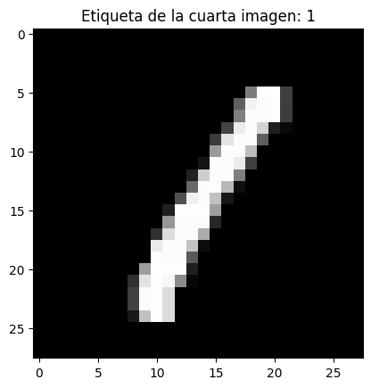

```python
# imagen de entrenamiento - ejemplo
plt.imshow(train_images[3], cmap='gray')
plt.title(f"Etiqueta de la cuarta imagen: {train_labels[3]}")
plt.show()
```

Next you will give the appropriate shape to the training and test datasets in order to put them into the neural network. Convert the labels, which right now are numbers, into their categorical form. Check the keras utils manual.

Seguidamente, se hace un preprocesamiento de los datos, donde primero se hace una reestructuración de los tensores para que tengan la forma (28,28,1) en lugar de (28,28), es decir, se añade un canal para indicar que la imagen es en blanco y negro. Esto se hace debido a que las capas convolucionales esperan un tensor de entrada con la forma (altura, anchura, canales); por lo cual, es necesario expandir la dimensión para reflejar este canal. Luego, se normaliza cada valor a un rango 0-1 dividiendo entre 255, lo que ayuda a la red a entrenar más rápido y con mayor estabilidad numérica. Esto se hace debido a que las imágenes vienen con valores de intensidad de píxel en el rango 0-255.

```python
# normalizacion
train_images = train_images.reshape((60000, 28, 28, 1))
train_images = train_images.astype('float32') / 255

test_images = test_images.reshape((10000, 28, 28, 1))
test_images = test_images.astype('float32') / 255

train_images.shape, test_images.shape
```

```
((60000, 28, 28, 1), (10000, 28, 28, 1))
```

Seguidamente, se hace una codificación de etiquetas a one-hot-encoding para entrenar al model y usar la función de pérdida categorical_crossentropy. Es importante mencionar que, este proceso podría no hacerse y se usa la función de perdida sparse_categorical_crossentropy. Al transformar un vector one-hot-encoding, lo que se hace es convertir un vector de etiquetas enteras a una matriz donde cada etiqueta está representada por un vector que tiene un 1 en la posición correspondiente al valor y 0 en las demás. Ejemplo [0, 0, 0, 0, 0, 1, 0, 0, 0, 0] = 5

```python
#One-hot encoding de las etiquetas
train_labels = tf.keras.utils.to_categorical(train_labels, 10)
test_labels  = tf.keras.utils.to_categorical(test_labels, 10)

#verificación de que las etiquetas son one-hot
train_labels[:5], test_labels[:5]
```

```
(array([[0., 0., 0., 0., 0., 1., 0., 0., 0., 0.],
        [1., 0., 0., 0., 0., 0., 0., 0., 0., 0.],
        [0., 0., 0., 0., 1., 0., 0., 0., 0., 0.],
        [0., 1., 0., 0., 0., 0., 0., 0., 0., 0.],
        [0., 0., 0., 0., 0., 0., 0., 0., 0., 1.]], dtype=float32),
 array([[0., 0., 0., 0., 0., 0., 0., 1., 0., 0.],
        [0., 0., 1., 0., 0., 0., 0., 0., 0., 0.],
        [0., 1., 0., 0., 0., 0., 0., 0., 0., 0.],
        [1., 0., 0., 0., 0., 0., 0., 0., 0., 0.],
        [0., 0., 0., 0., 1., 0., 0., 0., 0., 0.]], dtype=float32))
```

Compile the model indicating what the training data and its labels are. Using the optimizer "rmsprop" and as a loss function use the categorical cross entropy. Then train the model for 5 epochs and a batch size of 64.

Primero se compila el modelo con el optimizador "rmsprop", el cual es un método de optimización adaptativa (similar a Adam); la función de pérdida "categorical_crossentropy", dado que las etiquetas están en one-hot (como se explicó anteriormente), siendo adecuada para un problema de clasificación multiclase; y finalmente una métrica "accuracy", la cual mostrará la exactitud durante el entrenamiento y evaluación.

```python
model.compile(optimizer='rmsprop',
              loss='categorical_crossentropy',
              metrics=['accuracy'])
```

Luego se entrena el modelo con 5 épocas y batch size de 64. En este entrenamiento se ajustan los pesos de la red neuronal, donde en cada época, la red verá todos los ejemplos de entrenamiento, dividirá el dataset en lotes (batch_size) y actualizará los pesos gradualmente para reducir la pérdida.

```python
history = model.fit(train_images, train_labels, epochs=5, batch_size=64)
```

[output not shown]

Let's evaluate the model with the test images:

Una vez entrenado el modelo, para medir el rendimiento real se usa un conjunto de datos que la red no ha visto durante el entrenamiento, el cual es el dataset de imagenes y etiquetas de test. De esta manera, de acuerdo con los resultados de métrica se sabrás si el modelo generaliza bien.

```python
test_loss, test_acc = model.evaluate(test_images, test_labels)
print("Pérdida en el conjunto de prueba:", test_loss)
print("Exactitud en el conjunto de prueba (accuracy):", test_acc)
```

```
Pérdida en el conjunto de prueba: 0.03588269278407097
Exactitud en el conjunto de prueba (accuracy): 0.9894000291824341
```

Al evaluar el modelo con las 10.000 imágenes de prueba, se obtiene un resultado de pérdida de 0.03, el cual es bastante bajo e indica que el modelo predice de manera precisa y se ajusta a los datos. Por su parte, el accuracy o precisión es de 0.99 aproximadamente, indicando que de 100 imágenes el modelo clasifica correctamente 99.

Ambas métricas dan unos buenos resultados, indicando que el modelo reconoce de manera eficaz los dígitos, generalizando bien, con pocos errores y alta precisión en los datos no vistos durante el entrenamiento.

Create an image with a handwritting number and check the prediction.

Se carga una imagen con un número escrito a mano para posteriormente probar el modelo. La imagen se debe preprocesar para adaptarla al formato que el modelo espera (28x28, con un canal). Para esto, se lee el archivo, se redimensiona la imagen, se carga a blanco y negro (1 canal), se convierte en un array de numpy y Expandir las dimensiones para que tenga la forma (1, 28, 28, 1). Finalmente se muestra la imagen.

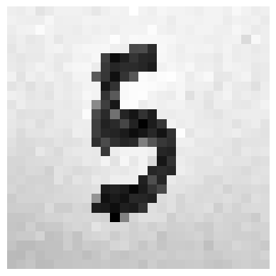

```python
import tensorflow as tf
from tensorflow.keras.preprocessing import image

img_width = 28
img_height = 28

# Cargar la imagen con TensorFlow (use the image generated by you)
img = tf.keras.preprocessing.image.load_img('cinco.jpg', target_size=(img_width, img_height), color_mode="grayscale")
# Convertir la imagen a un array numpy
x = tf.keras.preprocessing.image.img_to_array(img)
# Normalización
x = x.astype('float32') / 255
# Expandir las dimensiones para que tenga la forma (1, img_width, img_height, 1)
x = np.expand_dims(x, axis=0)

# Mostrar la imagen
plt.imshow(x[0, :, :, 0], cmap='gray')
plt.axis('off')
plt.show()
```

```python
model.save('net_numbers.h5')
```

Load the model that you just saved and make a prediction with the number you just generated. Try with several numbers ...does it work properly? Explain why do you think this happens.

Se carga el modelo previamente entrenado y se prueba la predicción con el número generado anteriormente.

```python
modelo_cargado = load_model("net_numbers.h5")
print("Modelo cargado exitosamente.")

# Prueba de la imagen cargada
pred_cargado = modelo_cargado.predict(x)
clase_pred_cargado = np.argmax(pred_cargado, axis=1)
print("Dígito predicho por el modelo cargado:", clase_pred_cargado[0])
```

```
Modelo cargado exitosamente.
Dígito predicho por el modelo cargado: 5
```

Se hacen otras dos pruebas de números.

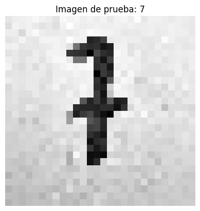

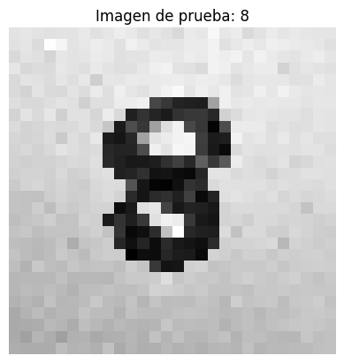

```python
# Cargar la imagen
siete = tf.keras.preprocessing.image.load_img('siete.jpg', target_size=(img_width, img_height), color_mode="grayscale")
siete = tf.keras.preprocessing.image.img_to_array(siete)
siete = siete.astype('float32') / 255
siete = np.expand_dims(siete, axis=0)

ocho = tf.keras.preprocessing.image.load_img('ocho.jpg', target_size=(img_width, img_height), color_mode="grayscale")
ocho = tf.keras.preprocessing.image.img_to_array(ocho)
ocho = ocho.astype('float32') / 255
ocho = np.expand_dims(ocho, axis=0)

# Mostrar la imagen
plt.imshow(siete[0, :, :, 0], cmap='gray')
plt.axis('off')
plt.title("Imagen de prueba: 7")
plt.show()

plt.imshow(ocho[0, :, :, 0], cmap='gray')
plt.axis('off')
plt.title("Imagen de prueba: 8")
plt.show()
```

```python
# predecir la clase de la imagen
pred_siete = modelo_cargado.predict(siete)
clase_pred_siete = np.argmax(pred_siete, axis=1)
print("Dígito predicho por el modelo cargado:", clase_pred_siete[0])
# predecir la clase de la imagen
pred_ocho = modelo_cargado.predict(ocho)
clase_pred_ocho = np.argmax(pred_ocho, axis=1)
print("Dígito predicho por el modelo cargado:", clase_pred_ocho[0])
```

```
Dígito predicho por el modelo cargado: 4
Dígito predicho por el modelo cargado: 0
```

Dos de las tres imágenes cargadas son mal predichas por el modelo, y sus predicciones no son coherentes frente a la confusión de números por errores en escritura o porque sean parecidos. Además, hay que recordar que el modelo tuvo una métrica de precisión del 99% aproximadamente, por lo cual esto no debería pasar.

Es importante mencionar, que quizás como la imagen es de una cámara el fondo blanco se observa con un poco de ruido, mostrándose un poco gris por las sombras que se pueden generar al tomar la foto. Esto podría ser un factor que este ocacionando el error en la predicción. Ahora bien, es importante revisar los datos de entrenamiento y sus caracteristicas. Por tal razón, se revisa un poco más de cómo es la estructura de varios números que se utilizaron en el dataset de train para entrenar el modelo.

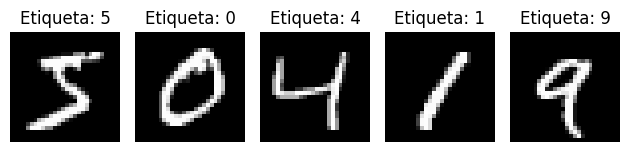

```python
#ejemplos de 5 números del dataset de train
for i in range(5):
    plt.subplot(1, 5, i + 1)
    plt.imshow(train_images[i].reshape(28, 28), cmap='gray')
    plt.axis('off')
    plt.title(f"Etiqueta: {np.argmax(train_labels[i])}")
plt.tight_layout()
plt.show()
```

Las imágenes del dataset de entrenamiento tienen fondo negro y los números son escritos con blanco, pero las predichas anteriormente son fondo blanco y los números en color negro. Para probar si el error en las predicciones se debe al formato se podríamos probar el recrear el mismo formato (fondo negro y número blanco) bajo las mismas condiciones de luz y la cámara, para identificar si este aspecto es relevante.

Se hace tres pruebas de números, pero se cambia el fondo y color del número acorde al formato de entrenamiento.

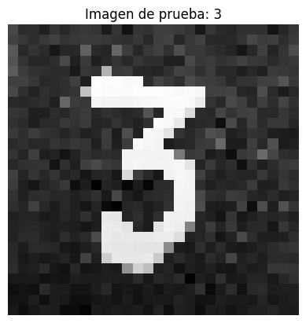

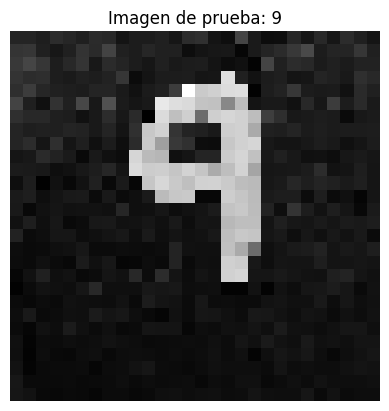

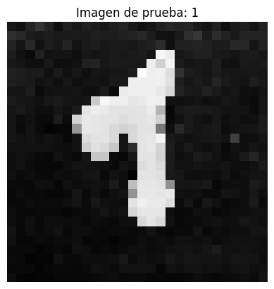

```python
# Cargar la imagen
tres = tf.keras.preprocessing.image.load_img('tres.jpg', target_size=(img_width, img_height), color_mode="grayscale")
tres = tf.keras.preprocessing.image.img_to_array(tres)
tres = tres.astype('float32') / 255
tres = np.expand_dims(tres, axis=0)

nueve = tf.keras.preprocessing.image.load_img('nueve.jpg', target_size=(img_width, img_height), color_mode="grayscale")
nueve = tf.keras.preprocessing.image.img_to_array(nueve)
nueve = nueve.astype('float32') / 255
nueve = np.expand_dims(nueve, axis=0)

uno = tf.keras.preprocessing.image.load_img('uno.jpg', target_size=(img_width, img_height), color_mode="grayscale")
uno = tf.keras.preprocessing.image.img_to_array(uno)
uno = uno.astype('float32') / 255
uno = np.expand_dims(uno, axis=0)

# Mostrar la imagen
plt.imshow(tres[0, :, :, 0], cmap='gray')
plt.axis('off')
plt.title("Imagen de prueba: 3")
plt.show()

plt.imshow(nueve[0, :, :, 0], cmap='gray')
plt.axis('off')
plt.title("Imagen de prueba: 9")
plt.show()

plt.imshow(uno[0, :, :, 0], cmap='gray')
plt.axis('off')
plt.title("Imagen de prueba: 1")
plt.show()
```

```python
# predecir la clase de la imagen tres
pred_tres = modelo_cargado.predict(tres)
clase_pred_tres = np.argmax(pred_tres, axis=1)
print("Dígito predicho por el modelo cargado:", clase_pred_tres[0])
# predecir la clase de la imagen nueve
pred_nueve = modelo_cargado.predict(nueve)
clase_pred_nueve = np.argmax(pred_nueve, axis=1)
print("Dígito predicho por el modelo cargado:", clase_pred_nueve[0])
# predecir la clase de la imagen uno
pred_uno = modelo_cargado.predict(uno)
clase_pred_uno = np.argmax(pred_uno, axis=1)
print("Dígito predicho por el modelo cargado:", clase_pred_uno[0])
```

```
Dígito predicho por el modelo cargado: 3
Dígito predicho por el modelo cargado: 9
Dígito predicho por el modelo cargado: 1
```

Pese a que el fondo y el número tienen un poco de ruido debido a la calidad de la imagen generada por la cámara, los números predichos en estas tres pruebas son correctos. Con esto se puede observar que el modelo no funciona correctamente cuando se cambia un poco las características de la imagen con respecto a las usadas en el entrenamiento; sin embargo, al usar unas imágenes que cumplen un patrón similar, el modelo predice de manera adecuada. Esto se debe a que el modelo aprendió los patrones específicos del dataset de MNIST (color, borde, resolución, márgenes, ubicación), y un cambio en estos hace que no pueda predecir correctamente.

Es importante mencionar que, estas imágenes usadas para la predicción tienen un poco de ruido por ser tomadas desde una cámara, donde puede haber sombras o variaciones de luz. Además, el fondo negro fue recreado con marcador, por lo cual tampoco es una imagen muy limpia. Sin embargo, estos últimos números están más cerca del patrón aprendido por el modelo, obteniendo una predicción correcta.

Para mejorar el modelo se podría entrenar con un dataset que contenga distintos estilos de fondo y color, invirtiendo colores, añadiendo ruido, rotaciones ligeras, cambios de brillo, entre otras. Así, la red aprendería a reconocer dígitos en condiciones más variadas y no sólo en el estilo estricto de MNIST. De esta manera, se obtendría un modelo más robusto que es capaz de interpretar cambios o ruidos en las imágenes reales para hacer una buena predicción.

Finalmente, para el funcionamiento de este modelo pese al fondo, se podrían invertir los colores de las imágenes de fondo blanco para que se pueda predecir adecuadamente el número.

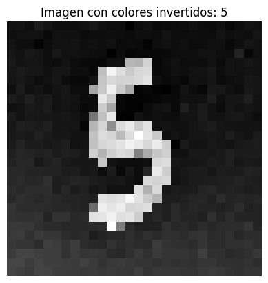

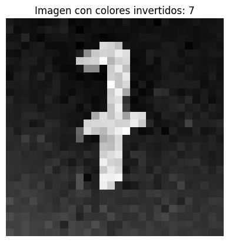

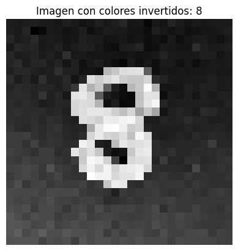

```python
img_cinco = tf.keras.preprocessing.image.load_img('cinco.jpg',target_size=(img_width, img_height), color_mode='grayscale')
img_cinco = tf.keras.preprocessing.image.img_to_array(img_cinco)
img_cinco = 255 - img_cinco
img_cinco = img_cinco.astype('float32') / 255
img_cinco = np.expand_dims(img_cinco, axis=0)

img_siete = tf.keras.preprocessing.image.load_img('siete.jpg',target_size=(img_width, img_height), color_mode='grayscale')
img_siete = tf.keras.preprocessing.image.img_to_array(img_siete)
img_siete = 255 - img_siete
img_siete = img_siete.astype('float32') / 255
img_siete = np.expand_dims(img_siete, axis=0)

img_ocho = tf.keras.preprocessing.image.load_img('ocho.jpg',target_size=(img_width, img_height), color_mode='grayscale')
img_ocho = tf.keras.preprocessing.image.img_to_array(img_ocho)
img_ocho = 255 - img_ocho
img_ocho = img_ocho.astype('float32') / 255
img_ocho = np.expand_dims(img_ocho, axis=0)

# Visualización invertida
plt.imshow(img_cinco[0, :, :, 0], cmap='gray')
plt.title("Imagen con colores invertidos: 5")
plt.axis('off')
plt.show()

plt.imshow(img_siete[0, :, :, 0], cmap='gray')
plt.title("Imagen con colores invertidos: 7")
plt.axis('off')
plt.show()

plt.imshow(img_ocho[0, :, :, 0], cmap='gray')
plt.title("Imagen con colores invertidos: 8")
plt.axis('off')
plt.show()
```

```python
# Predicción
pred_cinco = model.predict(img_cinco)
clase_pred_cinco = np.argmax(pred_cinco, axis=1)
print("Dígito predicho por el modelo:", clase_pred_cinco[0])

pred_siete = model.predict(img_siete)
clase_pred_siete = np.argmax(pred_siete, axis=1)
print("Dígito predicho por el modelo:", clase_pred_siete[0])

pred_ocho = model.predict(img_ocho)
clase_pred_ocho = np.argmax(pred_ocho, axis=1)
print("Dígito predicho por el modelo:", clase_pred_ocho[0])
```

```
Dígito predicho por el modelo: 5
Dígito predicho por el modelo: 3
Dígito predicho por el modelo: 8
```

Los resultados muestran una mejora en la predicción, sin embargo, uno de los números no logro ser predicho adecuadamente. Esto confirma que el modelo continúa siendo sensible a otros elementos como la luz, bordes, posiciones, ruido, entre otros. Además, hay que recordar que al modelo no se le configuro padding, por lo cual puede que este omitiendo algunas características importantes en los bordes, recortando la imagen. Para mejorar, se podría usar padding=same, y como se mencionó anteriormente se podría añadir data augmentation (rotaciones, traslaciones, cambios de iluminación, inversión de color), generando un dataset que refleje distintas situaciones reales. Con estas medidas, el modelo sería más robusto a variaciones, obteniendo mejores predicciones.

Es importante mencionar que, ante un dataset más robusto (estilos de dígitos, fondos, ángulos, iluminaciones, etc) podría ser necesario aumentar la complejidad de la red con más capas y/o neuronas para captar patrones más complejos y evitar subajuste. Sin embargo, esto debe balancearse con el riesgo de sobreajuste y el costo computacional.